# simple_audio

## Setup

Import necessary modules and dependencies.

```python
import os
import pathlib

import matplotlib.pyplot as plt
import numpy as np
import seaborn as sns
import tensorflow as tf

from tensorflow.keras.layers.experimental import preprocessing
from tensorflow.keras import layers
from tensorflow.keras import models
from IPython import display


# Set seed for experiment reproducibility
seed = 42
tf.random.set_seed(seed)
np.random.seed(seed)
```

```python
commands = ['Bark', 'Bow-wow', 'Growling', 'Howl', 'Whimper', 'Yip']
import glob
all_files = {
    'Bark':{
        'train_files': [],
        'val_files': [],
        'test_files': []
    },
    'Bow-wow':{
        'train_files': [],
        'val_files': [],
        'test_files': []
    },
    'Growling':{
        'train_files': [],
        'val_files': [],
        'test_files': []
    },
    'Howl':{
        'train_files': [],
        'val_files': [],
        'test_files': []
    },
    'Whimper':{
        'train_files': [],
        'val_files': [],
        'test_files': []
    },
    'Yip':{
        'train_files': [],
        'val_files': [],
        'test_files': []
    }
}

for i in commands:
    filenames = glob.glob(str(i) + '/cropped/16bit/*.wav')
    all_files[i]['train_files'] = filenames[:150]
    all_files[i]['val_files'] = filenames[150:200]
    all_files[i]['test_files'] = filenames[200:]

import json
with open('filenames.json', 'w') as file:
    json.dump(all_files, file)
```

## Reading audio files and their labels

The audio file will initially be read as a binary file, which you'll want to convert into a numerical tensor.

To load an audio file, you will use [`tf.audio.decode_wav`](https://www.tensorflow.org/api_docs/python/tf/audio/decode_wav), which returns the WAV-encoded audio as a Tensor and the sample rate.

A WAV file contains time series data with a set number of samples per second. Each sample represents the amplitude of the audio signal at that specific time. In a 16-bit system, like the files in `mini_speech_commands`, the values range from -32768 to 32767. The sample rate for this dataset is 16kHz. Note that `tf.audio.decode_wav` will normalize the values to the range [-1.0, 1.0].

```python
def decode_audio(audio_binary):
  audio, _ = tf.audio.decode_wav(audio_binary)
  return tf.squeeze(audio, axis=-1)
```

```python
def get_label(file_path):
  if tf.strings.split(file_path, '/')[0] == 'Yip' or tf.strings.split(file_path, '/')[0] == 'Whimper':
    return 'yes'
  return 'no'
```

Let's define a method that will take in the filename of the WAV file and output a tuple containing the audio and labels for supervised training.

```python
def get_waveform_and_label(file_path):
  label = get_label(file_path)
  audio_binary = tf.io.read_file(file_path)
  waveform = decode_audio(audio_binary)
  return waveform, label
```

You will now apply `process_path` to build your training set to extract the audio-label pairs and check the results. You'll build the validation and test sets using a similar procedure later on.

```python
AUTOTUNE = tf.data.AUTOTUNE
with open('filenames.json') as f:
    all_filenames = json.load(f)
train_files = []
for i in commands:
    train_files.extend(all_filenames[i]['train_files'])
ignore = [2, 4, 7, 10, 11, 13, 20, 23, 25, 28, 32, 34, 37, 38, 41, 48, 50, 54, 56, 58, 60, 61, 62, 63, 70, 73, 74, 81, 82, 84, 85, 86, 88, 97, 99, 100, 101, 104, 110, 111, 113, 114, 122, 124, 128, 129, 130, 132, 135, 140, 145, 150, 151, 156, 159, 163, 164, 165, 167, 172, 173, 178, 181, 187, 189, 190, 196, 201, 203, 206, 207, 209, 210, 211, 215, 217, 222, 225, 226, 228, 232, 233, 234, 238, 240, 243, 245, 249, 250, 251, 254, 256, 258, 260, 265, 266, 270, 274, 276, 277, 279, 282, 283, 284, 285, 290, 294, 297, 299, 300, 306, 307, 310, 314, 315, 318, 322, 325, 326, 330, 334, 336, 341, 344, 347, 348, 358, 359, 362, 366, 369, 376, 377, 378, 382, 387, 389, 390, 391, 393, 394, 395, 396, 400, 403, 405, 408, 410, 411, 415, 416, 418, 419, 420, 422, 427, 433, 434, 435, 437, 440, 441, 442, 445, 446, 447, 450, 454, 456, 458, 460, 463, 464, 466, 467, 469, 470, 473, 474, 475, 476, 482, 487, 488, 489, 491, 493, 494, 504, 505, 506, 508, 509, 511, 513, 515, 516, 520, 521, 524, 526, 529, 532, 536, 537, 541, 543, 544, 546, 547, 548, 552, 562, 566, 569, 571, 573, 577, 578, 579, 584, 585, 586, 588, 590, 591, 594, 596, 605, 608, 609, 616, 618, 620, 628, 631, 635, 638, 644, 646, 647, 651, 654, 658, 661, 664, 670, 671, 672, 673, 674, 675, 678, 679, 680, 681, 684, 686, 689, 692, 694, 699, 701, 702, 706, 707, 709, 710, 716, 720, 721, 723, 729, 730, 733, 734, 738, 742, 747, 748, 749, 751, 752, 753, 760, 761, 762, 765, 770, 773, 775, 776, 777, 778]
for i in ignore:
    train_files[i] = None
train_files = list(filter(None, train_files))
files_ds = tf.data.Dataset.from_tensor_slices(train_files)
waveform_ds = files_ds.map(get_waveform_and_label, num_parallel_calls=AUTOTUNE)
```

```
Tensor("DecodeWav:0", shape=(None, None), dtype=float32)
```

## Spectrogram

You'll convert the waveform into a spectrogram, which shows frequency changes over time and can be represented as a 2D image. This can be done by applying the short-time Fourier transform (STFT) to convert the audio into the time-frequency domain.

A Fourier transform ([`tf.signal.fft`](https://www.tensorflow.org/api_docs/python/tf/signal/fft)) converts a signal to its component frequencies, but loses all time information. The STFT ([`tf.signal.stft`](https://www.tensorflow.org/api_docs/python/tf/signal/stft)) splits the signal into windows of time and runs a Fourier transform on each window, preserving some time information, and returning a 2D tensor that you can run standard convolutions on.

STFT produces an array of complex numbers representing magnitude and phase. However, you'll only need the magnitude for this tutorial, which can be derived by applying `tf.abs` on the output of `tf.signal.stft`.

```python
def get_spectrogram(waveform):
  # Padding for files with less than 16000 samples
  #zero_padding = tf.zeros([16000] - tf.shape(waveform), dtype=tf.float32)

  # Concatenate audio with padding so that all audio clips will be of the
  # same length
  waveform = tf.cast(waveform, tf.float32)
  equal_length = tf.concat([waveform], 0)
  spectrogram = tf.signal.stft(
      equal_length, frame_length=255, frame_step=128)
  print(spectrogram.shape)
  spectrogram = tf.abs(spectrogram)

  return spectrogram
```

Next, you will explore the data. Compare the waveform, the spectrogram and the actual audio of one example from the dataset.

```python
for waveform, label in waveform_ds.take(1):
  label = label.numpy().decode('utf-8')
  spectrogram = get_spectrogram(waveform)

print('Label:', label)
print('Waveform shape:', waveform.shape)
print('Spectrogram shape:', spectrogram.shape)
print('Audio playback')
display.display(display.Audio(waveform, rate=16000))
```

```
(3099, 129)
Label: no
Waveform shape: (396900,)
Spectrogram shape: (3099, 129)
Audio playback
```

[interactive chart not shown]

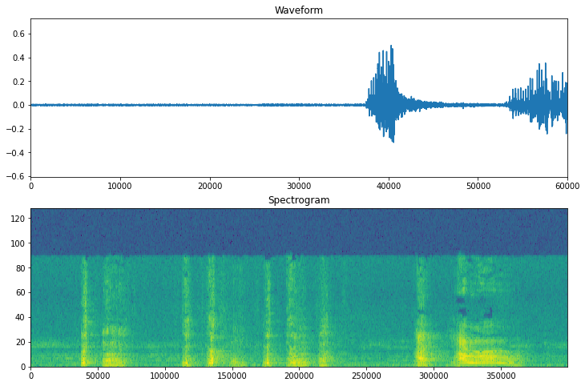

```python
def plot_spectrogram(spectrogram, ax):
  # Convert to frequencies to log scale and transpose so that the time is
  # represented in the x-axis (columns).
  log_spec = np.log(spectrogram.T)
  height = log_spec.shape[0]
  width = log_spec.shape[1]
  X = np.linspace(0, np.size(spectrogram), num=width, dtype=int)
  Y = range(height)
  ax.pcolormesh(X, Y, log_spec)


fig, axes = plt.subplots(2, figsize=(12, 8))
timescale = np.arange(waveform.shape[0])
axes[0].plot(timescale, waveform.numpy())
axes[0].set_title('Waveform')
axes[0].set_xlim([0, 60000])
plot_spectrogram(spectrogram.numpy(), axes[1])
axes[1].set_title('Spectrogram')
plt.show()
```

Now transform the waveform dataset to have spectrogram images and their corresponding labels as integer IDs.

```python
def get_spectrogram_and_label_id(audio, label):
  spectrogram = get_spectrogram(audio)
  spectrogram = tf.expand_dims(spectrogram, -1)
  labels=['yes', 'no']
  label_id = tf.argmax(label == labels)
  return spectrogram, label_id
```

```python
spectrogram_ds = waveform_ds.map(
    get_spectrogram_and_label_id, num_parallel_calls=AUTOTUNE)
```

```
(None, 129)
```

Examine the spectrogram "images" for different samples of the dataset.

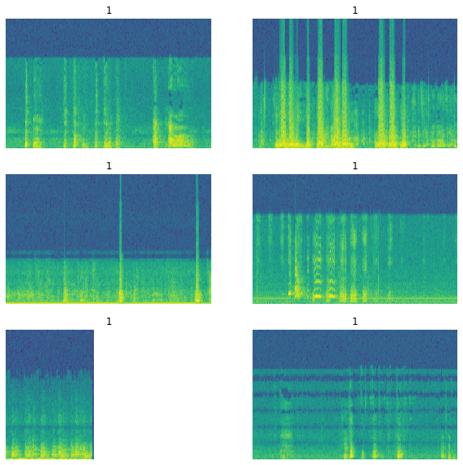

```python
rows = 3
cols = 2
n = rows*cols
fig, axes = plt.subplots(rows, cols, figsize=(10, 10))
for i, (spectrogram, label_id) in enumerate(spectrogram_ds.take(n)):
  r = i // cols
  c = i % cols
  ax = axes[r][c]
  plot_spectrogram(np.squeeze(spectrogram.numpy()), ax)
  ax.set_title(label_id.numpy())
  ax.axis('off')

plt.show()
```

## Build and train the model

Now you can build and train your model. But before you do that, you'll need to repeat the training set preprocessing on the validation and test sets.

```python
def preprocess_dataset(files):
    files_ds = tf.data.Dataset.from_tensor_slices(files)
    output_ds = files_ds.map(get_waveform_and_label, num_parallel_calls=AUTOTUNE)
    output_ds = output_ds.map(
        get_spectrogram_and_label_id,  num_parallel_calls=AUTOTUNE)
    return output_ds
```

```python
all_filenames = {}
with open('filenames.json') as f:
    all_filenames = json.load(f)
train_ds = spectrogram_ds

files_for_val = []
files_for_test = []
for i in commands:
    files_for_val.extend(all_filenames[i]['val_files'])
    files_for_test.extend(all_filenames[i]['test_files'])

ignore_val=[4, 6, 7, 11, 13, 18, 28, 29, 32, 34, 36, 39, 40, 44, 46, 51, 54, 56, 61, 63, 65, 66, 68, 69, 71, 73, 75, 77, 79, 82, 83, 86, 90, 93, 96, 98]
ignore_test=[1, 3, 5, 7]
for i in ignore_val:
    files_for_val[i] = None
files_for_val = list(filter(None, files_for_val))

for i in ignore_test:
    files_for_test[i] = None
files_for_test = list(filter(None, files_for_test))

val_ds = preprocess_dataset(files_for_val)
test_ds = preprocess_dataset(files_for_test)
```

```
Tensor("DecodeWav:0", shape=(None, None), dtype=float32)
(None, 129)
Tensor("DecodeWav:0", shape=(None, None), dtype=float32)
(None, 129)
```

Batch the training and validation sets for model training.

```python
batch_size = 10
train_ds = train_ds.batch(batch_size)
val_ds = val_ds.batch(batch_size)
```

Add dataset [`cache()`](https://www.tensorflow.org/api_docs/python/tf/data/Dataset#cache) and [`prefetch()`](https://www.tensorflow.org/api_docs/python/tf/data/Dataset#prefetch) operations to reduce read latency while training the model.

```python
train_ds = train_ds.cache().prefetch(AUTOTUNE)
val_ds = val_ds.cache().prefetch(AUTOTUNE)
```

For the model, you'll use a simple convolutional neural network (CNN), since you have transformed the audio files into spectrogram images. The model also has the following additional preprocessing layers:

- A [`Resizing`](https://www.tensorflow.org/api_docs/python/tf/keras/layers/experimental/preprocessing/Resizing) layer to downsample the input to enable the model to train faster.
- A [`Normalization`](https://www.tensorflow.org/api_docs/python/tf/keras/layers/experimental/preprocessing/Normalization) layer to normalize each pixel in the image based on its mean and standard deviation.

For the `Normalization` layer, its `adapt` method would first need to be called on the training data in order to compute aggregate statistics (i.e. mean and standard deviation).

```python
for spectrogram, _ in spectrogram_ds.take(1):
  input_shape = spectrogram.shape

norm_layer = preprocessing.Normalization()
norm_layer.adapt(spectrogram_ds.map(lambda x, _: x))

model = models.Sequential([
    layers.Input(shape=input_shape),
    preprocessing.Resizing(32, 32),
    norm_layer,
    layers.Conv2D(32, 3, activation='relu'),
    layers.Conv2D(64, 3, activation='relu'),
    layers.MaxPooling2D(),
    layers.Dropout(0.25),
    layers.Flatten(),
    layers.Dense(128, activation='relu'),
    layers.Dropout(0.5),
    layers.Dense(2),
])

model.summary()
```

```
Model: "sequential_7"
_________________________________________________________________
Layer (type)                 Output Shape              Param #
=================================================================
resizing_7 (Resizing)        (None, 32, 32, 1)         0
_________________________________________________________________
normalization_7 (Normalizati (None, 32, 32, 1)         3
_________________________________________________________________
conv2d_14 (Conv2D)           (None, 30, 30, 32)        320
_________________________________________________________________
conv2d_15 (Conv2D)           (None, 28, 28, 64)        18496
_________________________________________________________________
max_pooling2d_7 (MaxPooling2 (None, 14, 14, 64)        0
_________________________________________________________________
dropout_14 (Dropout)         (None, 14, 14, 64)        0
_________________________________________________________________
flatten_7 (Flatten)          (None, 12544)             0
_________________________________________________________________
dense_14 (Dense)             (None, 128)               1605760
_________________________________________________________________
dropout_15 (Dropout)         (None, 128)               0
_________________________________________________________________
dense_15 (Dense)             (None, 2)                 258
=================================================================
Total params: 1,624,837
Trainable params: 1,624,834
Non-trainable params: 3
_________________________________________________________________
```

```python
model.compile(
    optimizer=tf.keras.optimizers.Adam(),
    loss=tf.keras.losses.SparseCategoricalCrossentropy(from_logits=True),
    metrics=['accuracy'],
)
```

```python
EPOCHS = 10
history = model.fit(
    train_ds,
    validation_data=val_ds,
    epochs=EPOCHS,
    callbacks=tf.keras.callbacks.EarlyStopping(verbose=1, patience=2),
)
model.save('saved_model')
```

```
INFO:tensorflow:Assets written to: saved_model/assets
```

Let's check the training and validation loss curves to see how your model has improved during training.

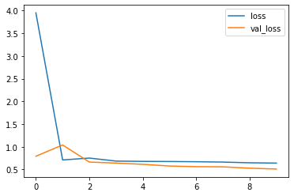

```python
metrics = history.history
plt.plot(history.epoch, metrics['loss'], metrics['val_loss'])
plt.legend(['loss', 'val_loss'])
plt.show()
```